# Composer CMS: Content Make System

Gary B. Genett

v3.1 (2024-08-10)

# Composer CMS

|  | “Creating Made Simple.” |
| --- | --- |
| [Composer CMS v3.1](https://github.com/garybgenett/composer/tree/v3.1) | License: GPL |
| [Gary B. Genett](http://www.garybgenett.net/projects/composer) | composer@garybgenett.net |

– Formats: webpage / html / pdf / epub / revealjs.html / docx

## Overview

**[Composer](http://www.garybgenett.net/projects/composer) is a simple but powerful CMS based on [Pandoc], [Bootstrap] and [GNU Make].** It is a document and website build system that processes directories or individual files in [Markdown] format.

Traditionally, CMS stands for Content Management System. [Composer](http://www.garybgenett.net/projects/composer) is designed to be a Content **Make** System. Written content is vastly easier to manage as plain text, which can be crafted with simple editors and tracked with revision control. However, professional documentation, publications, and websites require formatting that is dynamic and feature-rich.

[Pandoc] is an extremely powerful document conversion tool, and is a widely used standard for processing [Markdown] into other formats. While it has reasonable defaults, there are a large number of options, and additional tools are required for some formats and features.

[Composer](http://www.garybgenett.net/projects/composer) consolidates all the necessary components, simplifies the options, and prettifies the output formats, all in one place. It also serves as a build system, so that large repositories can be managed as documentation archives or published as [Static Websites].

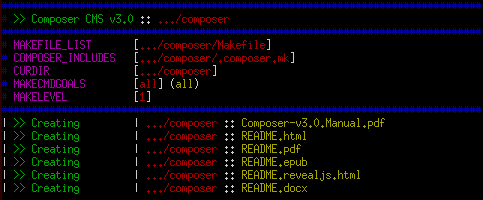

## Quick Start

Use `make help` to get started:

```
make [-f .../Makefile] [variables] <filename>.<extension>
make [-f .../Makefile] [variables] <target>
```

Create documents from source [Markdown] files (see Formatting Variables):

```
make README.html
make Composer-v3.1.Manual.html c_list="README.md LICENSE.md"
```

Save a persistent configuration (see [Recommended Workflow] and [Configuration Settings]):

```
make template >.composer.mk
$EDITOR .composer.mk
    override COMPOSER_TARGETS := .targets Composer-v3.1.Manual.html
    override Composer-v3.1.Manual.html := README.md LICENSE.md
make clean
make all
```

Recursively install and build an entire directory tree (see [Recommended Workflow]):

```
cd .../documents
make -f .../.Composer/Makefile init
make -f .../.Composer/Makefile install-all
make all-all
```

See `help-all` for full details and additional targets.

## Principles

The guiding principles of [Composer](http://www.garybgenett.net/projects/composer):

- All source files in readable plain text
- Professional output, suitable for publication
- Minimal dependencies, and entirely command-line driven
- Separate content and formatting; writing and publishing are independent
- Inheritance and dependencies; global, tree, directory and file overrides
- Fast; both to initiate commands and for processing to complete

Direct support for key document types (see [Document Formatting]):

- [Static Websites]
- [HTML]
- [PDF]
- [EPUB]
- [Reveal.js Presentations]
- [Microsoft Word & PowerPoint]

## Requirements

[Composer](http://www.garybgenett.net/projects/composer) has almost no external dependencies. All needed components are integrated directly into the repository, including [Pandoc] and [YQ]. [Composer](http://www.garybgenett.net/projects/composer) does require a minimal command-line environment based on [GNU] tools, particularly [GNU Make], which is standard for all [GNU/Linux] systems. The [Windows Subsystem for Linux] for Windows and [MacPorts] for macOS both provide suitable environments.

The one large external requirement is [TeX Live], and it can be installed using the package managers of each of the above systems. It is only necessary for creating [PDF] files.

Below are the versions of the components in the repository, and the tested versions of external tools for this iteration of [Composer](http://www.garybgenett.net/projects/composer). Use [check] to validate your system.

The versions of the integrated repositories can be changed, if desired (see [Repository Versions]).

| Repository | Commit | License |
| --- | --- | --- |
| [Pandoc] | 2.18 | GPL |
| [YQ] | v4.24.2 | MIT |
| [Bootstrap] | v5.1.3 | MIT |
| [Bootlint] | v1.1.0 | MIT |
| [Bootswatch] | v5.1.3 | MIT |
| [Font Awesome] | 6.1.2 | MIT / CC-BY |
| [Water.css] | d950cbc9f8607521587f | MIT |
| [Markdown Viewer] | 3bd40d84c071379440b3 | MIT |
| [Markdown Themes] | 6b3643d0f703727d8472 | None |
| [Reveal.js] | 4.3.1 | MIT |
| [Google Firebase] | v12.4.7 | MIT |

| Project | Composer Version |
| --- | --- |
| [GNU Bash] | 5.1.16 |
| – [GNU Coreutils] | 8.32 |
| – [GNU Findutils] | 4.9.0 |
| – [GNU Sed] | 4.8 |
| [GNU Make] | 4.3 |
| – [Pandoc] | 2.18 |
| – [YQ] | 4.24.2 |
| – [TeX Live] [PDF] | 2021 3.141592653-2.6-1.40.22 |
| Supporting Tools: | – |
| – [Git SCM] | 2.37.4 |
| – [GNU Diffutils] | 3.8 |
| – [Rsync] | 3.2.4 |

[Markdown Viewer] is included both for its CSS stylesheets, and for real-time rendering of [Markdown] files as they are being written. To install, follow the instructions in the `README.md`.

[Google Firebase] is only necessary for uploading via the [export-all] and [export-force] targets. Binaries are included in the repository, but do not seem to work with all versions of their respective operating systems. If the included binary fails, use `+update-firebase-tools` to build a local version (see [+update-*]).

# Composer CMS v3.1 :: Help

```
make [-f .../Makefile] [variables] <filename>.<extension>
make [-f .../Makefile] [variables] <target>
```

# Composer Variables

## Formatting Variables

| Variable | Purpose | Value |
| --- | --- | --- |
| [c_site] ~ `S` | Enable [Static Websites] |  |
| [c_type] ~ `T` | Desired output format | html |
| [c_base] ~ `B` | Base of output file |  |
| [c_list] ~ `L` | List of input files(s) |  |
| [c_lang] ~ `a` | Language for document headers | en-US |
| [c_logo] ~ `g` | Logo image ([HTML] formats) | logo.img |
| [c_icon] ~ `i` | Icon image ([HTML] formats) | icon.img |
| [c_css] ~ `c` | Location of CSS file | theme.html-default.css |
| [c_toc] ~ `t` | Table of contents depth |  |
| [c_level] ~ `l` | Chapter/slide header level | 2 |
| [c_margin] ~ `m` | Size of margins ([PDF]) | 0.8in |
| [c_options] ~ `o` | Custom Pandoc options |  |

| Values ([c_type]) | Format | Extension |
| --- | --- | --- |
| `html` | HyperText Markup Language | *.html |
| `pdf` | Portable Document Format | *.pdf |
| `epub` | Electronic Publication | *.epub |
| `revealjs` | Reveal.js Presentation | *.revealjs.html |
| `docx` | Microsoft Word | *.docx |
| `pptx` | Microsoft PowerPoint | *.pptx |
| `text` | Plain Text (well-formatted) | *.txt |
| `markdown` | Markdown (for testing) | *.md.txt |

- *Other [c_type] values will be passed directly to [Pandoc]*
- *Special [c_css] values:*
  - *`css_alt` = Use the alternate default stylesheet*
  - *`0` = Revert to the [Pandoc] default*
- *Special [c_toc] value: `0` = List all headers, and number sections*
- *Special [c_level] value: `0` = Varies by [c_type] (see [c_level])*
- *An empty [c_margin] value enables individual margins:*
  - *`c_margin_top` ~ `mt`*
  - *`c_margin_bottom` ~ `mb`*
  - *`c_margin_left` ~ `ml`*
  - *`c_margin_right` ~ `mr`*

## Control Variables

| Variable | Purpose | Value |
| --- | --- | --- |
| [MAKEJOBS] | Parallel processing threads | 1 `(makejobs)` |
| [COMPOSER_DEBUGIT] | Use verbose output | `(debugit)` |
| [COMPOSER_DOCOLOR] | Enable title/color sequences | `(boolean)` |
| [COMPOSER_INCLUDE] | Include all: `.composer.mk` | 1 `(boolean)` |
| [COMPOSER_DEPENDS] | Sub-directories first: [all] | `(boolean)` |
| [COMPOSER_KEEPING] | Log entries / cache files | 100 `(keeping)` |
| [COMPOSER_LOG] | Timestamped command log | .composer.log |
| [COMPOSER_EXT] | Markdown file extension | .md |
| [COMPOSER_TARGETS] | See: [all]/[clean] | [config]/[targets] |
| [COMPOSER_SUBDIRS] | See: [all]/[clean]/[install] | [config]/[targets] |
| [COMPOSER_EXPORTS] | See: [c_site]/[export] | [config] |
| [COMPOSER_IGNORES] | See: [c_site]/[export] | [config] |

- *[MAKEJOBS] ~ `J`*
- *[COMPOSER_DEBUGIT] ~ `V`*
- *[COMPOSER_DOCOLOR] ~ `C`*
- *[COMPOSER_KEEPING] ~ `K`*
- *`(makejobs)` = empty is disabled / number of threads / `0` is no limit*
- *`(debugit)` = empty is disabled / any value enables / `0` is full tracing*
- *`(keeping)` = empty is none / number to keep / `0` is no limit*
- *`(boolean)` = empty is disabled / any value enables*

## Helper Variables

| Variable | Purpose | Value |
| --- | --- | --- |
| [CURDIR] | [GNU Make] current directory | `$PWD` :: `make` |
| [COMPOSER_CURDIR] | Detects [COMPOSER_INCLUDE] | [CURDIR] :: `.composer.mk` |
| [COMPOSER_DIR] | Location of [Composer](http://www.garybgenett.net/projects/composer) | …/composer |
| [COMPOSER_ROOT] | Topmost level of current tree | …/composer |
| [COMPOSER_EXPORT] | Target: [export] | [COMPOSER_ROOT]/+Composer `(mk)` |
| [COMPOSER_LIBRARY] | Target: [site]/[site-library] | `(yml)` |
| [COMPOSER_SRC] | Repositories and downloads | [COMPOSER_DIR]/.sources |
| [COMPOSER_ART] | [Composer](http://www.garybgenett.net/projects/composer) supporting files | [COMPOSER_DIR]/_artifacts |
| [COMPOSER_DAT] | [Pandoc] supporting files | [COMPOSER_ART]/pandoc |
| [COMPOSER_TMP] | Cache and working directory | [CURDIR]/.composer.tmp |

- *`(mk)` = configurable in `.composer.mk`*
- *`(yml)` = configurable in `.composer.yml`*

# Composer Targets

## Primary Targets

| Target | Purpose |
| --- | --- |
| [help] | Basic help overview (default) |
| [help-all] | Console version of `README.md` (no reference sections) |
| [template] | Print settings template: `.composer.mk` |
| [template.yml] | Print settings template: `.composer.yml` |
| [template.md] | Print `markdown` file template |
| [compose] | Document creation engine (see [c_type]) |
| [site] | Build [HTML] files as [Static Websites] (see [c_site]) |
| [site-all] | Do [site] recursively: [COMPOSER_SUBDIRS] |
| [site-force] | Do [site] recursively: including [COMPOSER_LIBRARY] |
| [site-clean] | Remove [c_site] only: [COMPOSER_LIBRARY]/[COMPOSER_TMP] |
| [install] | Current directory initialization: `Makefile` |
| [install-all] | Do [install] recursively (no overwrite) |
| [install-force] | Recursively force overwrite of `Makefile` files |
| [clean] | Remove output files: [COMPOSER_TARGETS] :: [*-clean] |
| [clean-all] | Do [clean] recursively: [COMPOSER_SUBDIRS] |
| [*-clean] | Any targets named this way will also be run by [clean] |
| [all] | Create output files: [COMPOSER_TARGETS] :: [*-all] |
| [all-all] | Do [all] recursively: [COMPOSER_SUBDIRS] |
| [*-all] | Any targets named this way will also be run by [all] |
| [list] | Show updated files: `*`[COMPOSER_EXT] >> [COMPOSER_LOG] |

## Additional Targets

| Target | Purpose |
| --- | --- |
| [+release] | Upgrade all tools and supporting files to next versions |
| [+release-all] | Also make `README.*` files and [Static Websites] |
| [+update] | Update all included components (see Requirements) |
| [+update-all] | Additionally perform all source code builds |
| [+update-list] | Show changes made to each (see [Repository Versions]) |
| [+update-*] | Complete fetch and build for a specific component |
| [+debug] | Diagnostics, tests targets list in [COMPOSER_DEBUGIT] |
| [+debug-file] | Export [+debug] results to a plain text file |
| [check] | List system packages and versions (see Requirements) |
| [check-all] | Complete [check] package list, and system information |
| [config] | Show values of all Composer Variables |
| [config-all] | Complete [config], including environment variables |
| [config.*] | Export individual Composer Variables values |
| [config.yml] | JSON export of `.composer.yml` configuration |
| [targets] | List all available targets for the current directory |
| [init] | Create and link a `.Composer` in current directory |
| [commit] | [Git] commit of current directory tree or [c_list] |
| [commit-all] | Automatic [commit], without `$EDITOR` step |
| [export] | Synchronize `+Composer` export of [COMPOSER_ROOT] |
| [export-all] | Also publish to upstream hosting providers |
| [export-force] | Publish only, without synchronizing first |
| [*-export] | Any targets named this way will also be run by [export] |
| [site-library] | Build or update the [COMPOSER_LIBRARY] |
| [site-list] | [COMPOSER_LIBRARY] for current directory or [c_list] |
| [site-list-all] | Do [site-list] for current directory tree |
| [site-list-list] | All metadata fields and values, sorted by most used |
| [site-list-null] | List files which are missing metadata fields |
| [site-list.*] | Direct export of metadata or index, [c_list] searchable |

# Final Notes

## Command Examples

Create documents from source [Markdown] files (see Formatting Variables):

```
make README.html
make Composer-v3.1.Manual.html c_list="README.md LICENSE.md"
```

Save a persistent configuration (see [Recommended Workflow] and [Configuration Settings]):

```
make template >.composer.mk
$EDITOR .composer.mk
    override COMPOSER_TARGETS := .targets Composer-v3.1.Manual.html
    override Composer-v3.1.Manual.html := README.md LICENSE.md
make clean
make all
```

Recursively install and build an entire directory tree (see [Recommended Workflow]):

```
cd .../documents
make -f .../.Composer/Makefile init
make -f .../.Composer/Makefile install-all
make all-all
```

See `help-all` for full details and additional targets.

## Go Make A Thing

*Happy Making!*